# 1 Background

The outbreak of the novel Corona virus disease 2019 (COVID-19) was declared a public health emergency of international concern by the World Health Organization (WHO) on January 30, 2020. Upwards of [755 million cases have been confirmed worldwide, with nearly 6.8 million associated deaths](https://covid19.who.int/) by Feb of 2023. Within the US alone, there have been [over 1.1 million deaths and upwards of 102 million cases reported](https://covid.cdc.gov/covid-data-tracker/#trends_dailytrendscases) by Feb of 2023. Governments around the world have implemented and suggested a number of policies to lessen the spread of the pandemic, including mask-wearing requirements, travel restrictions, business and school closures, and even stay-at-home orders. The global pandemic has impacted the lives of individuals in countless ways, and though many countries have begun vaccinating individuals, the long-term impact of the virus remains unclear.

The impact of COVID-19 on a given segment of the population appears to vary drastically based on the socioeconomic characteristics of the segment. In particular, differing rates of infection and fatalities have been reported among different [racial groups](https://www.cdc.gov/coronavirus/2019-ncov/covid-data/investigations-discovery/hospitalization-death-by-race-ethnicity.html), [age groups](https://www.cdc.gov/coronavirus/2019-ncov/covid-data/investigations-discovery/hospitalization-death-by-age.html), and [socioeconomic groups](https://www.ncbi.nlm.nih.gov/pmc/articles/PMC7221360/). One of the most important metrics for determining the impact of the pandemic is the death rate, which is the proportion of people within the total population that die due to the the disease.

We assembled this dataset for our research with the goal of investigating the effectiveness of lockdowns in flattening the COVID curve. We are providing a portion of the cleaned dataset for this case study.

There are two main goals for this case study:

1.We aim to show the dynamic evolution of COVID cases and COVID-related deaths at the state level.

2. We aim to identify county-level demographic and policy interventions that are associated with mortality rates in the US. We will construct models to find possible factors related to county-level COVID-19 mortality rates.
3. This is a rather complex project, but with our team’s help, we have made your job easier.
4. Please hide all unnecessary lengthy R-output and keep your write-up neat and readable.

# 2 Data Summary

The data comes from several different sources:

1. [County-level infection and fatality data](https://github.com/nytimes/covid-19-data) - This dataset gives daily cumulative numbers on infection and fatality for each county.
   - [NYC data](https://github.com/nychealth/coronavirus-data)
2. [County-level socioeconomic data](https://www.ers.usda.gov/data-products/atlas-of-rural-and-small-town-america/download-the-data/) - The following are the four relevant datasets from this site.
   1. Income - Poverty level and household income.
   2. Jobs - Employment type, rate, and change.
   3. People - Population size, density, education level, race, age, household size, and migration rates.
   4. County Classifications - Type of county (rural or urban on a rural-urban continuum scale).
3. [Intervention Policy Data](https://github.com/JieYingWu/COVID-19_US_County-level_Summaries/blob/master/data/interventions.csv) - This dataset is a manually compiled list of the dates that interventions/lockdown policies were implemented and lifted at the county level.

# 3 EDA

In this case study, we use the following three nearly cleaned data:

- **covid_county.csv**: County-level socialeconomic information that combines the above-mentioned 4 datasets: Income (Poverty level and household income), Jobs (Employment type, rate, and change), People (Population size, density, education level, race, age, household size, and migration rates), County Classifications
- **covid_rates.csv**: Daily cumulative numbers on infection and fatality for each county
- **covid_intervention.csv**: County-level lockdown intervention.

Among all data, the unique identifier of county is `FIPS`.

The cleaning procedure is attached in `Appendix 2: Data cleaning` You may go through it if you are interested or would like to make any changes.

**It may need more data wrangling.**

First read in the data.

```r
# county-level socialeconomic information
county_data <- fread("/Users/nicholasmcgowan/Downloads/Homework 3/data/covid_county.csv")
# county-level COVID case and death
covid_rate <- fread("/Users/nicholasmcgowan/Downloads/Homework 3/data/covid_rates.csv")
# county-level lockdown dates
 covid_intervention <- fread("/Users/nicholasmcgowan/Downloads/Homework 3/data/covid_intervention.csv")
```

```r
  print(county_data)
```

```
##        FIPS State        County MedHHInc PerCapitaInc PovertyUnder18Pct
##    1:     0    US United States    61937        32621              18.0
##    2:  1000    AL       Alabama    49881        26846              23.9
##    3:  1001    AL       Autauga    59338        29372              19.3
##    4:  1003    AL       Baldwin    57588        31203              13.9
##    5:  1005    AL       Barbour    34382        18461              43.9
##   ---
## 3275: 72147    PR       Vieques       NA        11156                NA
## 3276: 72149    PR      Villalba       NA        10677                NA
## 3277: 72151    PR       Yabucoa       NA         9148                NA
## 3278: 72153    PR         Yauco       NA         8339                NA
## 3279: 72153    PR         Yauco       NA         8339                NA
##       PovertyAllAgesPct Deep_Pov_All Deep_Pov_Children PovertyUnder18Num
##    1:              13.1         6.25              8.60          12997532
##    2:              16.8         7.61             11.59            255613
```

[output cut: 729 more lines]

```r
  library(ggplot2)
```

```r
  print(covid_intervention)
```

```
##        FIPS STATE                        AREA_NAME stay at home >50 gatherings
##    1:  1000    AL                          alabama   2020-04-05     2020-03-21
##    2:  1001    AL                   autauga county   2020-04-05     2020-03-21
##    3:  1003    AL                   baldwin county   2020-04-05     2020-03-21
##    4:  1005    AL                   barbour county   2020-04-05     2020-03-21
##    5:  1007    AL                      bibb county   2020-04-05     2020-03-21
##   ---
## 3268: 72145    PR vega baja municipio, puerto rico         <NA>           <NA>
## 3269: 72147    PR   vieques municipio, puerto rico         <NA>           <NA>
## 3270: 72149    PR  villalba municipio, puerto rico         <NA>           <NA>
## 3271: 72151    PR   yabucoa municipio, puerto rico         <NA>           <NA>
## 3272: 72153    PR     yauco municipio, puerto rico         <NA>           <NA>
##       >500 gatherings public schools restaurant dine-in entertainment/gym
##    1:      2020-03-14     2020-03-17         2020-03-20        2020-03-29
##    2:      2020-03-14     2020-03-17         2020-03-20        2020-03-29
```

[output cut: 45 more lines]

## 3.1 Understand the data

The detailed description of variables is in `Appendix 1: Data description`. Please get familiar with the variables. Summarize the two data briefly.

## 3.2 COVID case trend

It is crucial to decide the right granularity for visualization and analysis. We will compare daily vs weekly total new cases by state and we will see it is hard to interpret daily report.

```r
  covid_data_filtered <- covid_rate[covid_rate$State %in% c("New York", "Washington", "Florida")]
  print(covid_data_filtered)
```

```
##         FIPS       date  County      State cum_cases cum_deaths week
##     1: 12001 2020-03-10 Alachua    Florida         1          0    8
##     2: 12001 2020-03-11 Alachua    Florida         1          0    8
##     3: 12001 2020-03-12 Alachua    Florida         2          0    8
##     4: 12001 2020-03-13 Alachua    Florida         3          0    8
##     5: 12001 2020-03-14 Alachua    Florida         3          0    8
##    ---
## 57106: 53077 2021-02-16  Yakima Washington     27045        410   57
## 57107: 53077 2021-02-17  Yakima Washington     27107        412   57
## 57108: 53077 2021-02-18  Yakima Washington     27177        413   57
## 57109: 53077 2021-02-19  Yakima Washington     27224        413   57
## 57110: 53077 2021-02-20  Yakima Washington     27279        413   57
##        TotalPopEst2019
##     1:          269043
##     2:          269043
##     3:          269043
##     4:          269043
##     5:          269043
##    ---
## 57106:          250873
## 57107:          250873
## 57108:          250873
## 57109:          250873
## 57110:          250873
```

```r
  covid_data_diff <- covid_data_filtered %>%
  mutate(diff_cases = cum_cases - lag(cum_cases, default = first(cum_cases)))
  print(covid_data_diff)
```

```
##         FIPS       date  County      State cum_cases cum_deaths week
##     1: 12001 2020-03-10 Alachua    Florida         1          0    8
##     2: 12001 2020-03-11 Alachua    Florida         1          0    8
##     3: 12001 2020-03-12 Alachua    Florida         2          0    8
##     4: 12001 2020-03-13 Alachua    Florida         3          0    8
##     5: 12001 2020-03-14 Alachua    Florida         3          0    8
##    ---
## 57106: 53077 2021-02-16  Yakima Washington     27045        410   57
## 57107: 53077 2021-02-17  Yakima Washington     27107        412   57
## 57108: 53077 2021-02-18  Yakima Washington     27177        413   57
## 57109: 53077 2021-02-19  Yakima Washington     27224        413   57
## 57110: 53077 2021-02-20  Yakima Washington     27279        413   57
##        TotalPopEst2019 diff_cases
##     1:          269043          0
##     2:          269043          0
##     3:          269043          1
##     4:          269043          1
##     5:          269043          0
##    ---
## 57106:          250873         75
## 57107:          250873         62
## 57108:          250873         70
## 57109:          250873         47
## 57110:          250873         55
```

1. Plot **new** COVID cases in NY, WA and FL by state and by day. Any irregular pattern? What is the biggest problem of using single day data? #New York

```r
  NYData <- covid_data_filtered[covid_data_filtered$State %in% c("New York")]

  print(NYData)
```

```
##         FIPS       date County    State cum_cases cum_deaths week
##     1: 36001 2020-03-12 Albany New York         2          0    8
##     2: 36001 2020-03-13 Albany New York         2          0    8
##     3: 36001 2020-03-14 Albany New York         5          0    8
##     4: 36001 2020-03-15 Albany New York        11          0    9
##     5: 36001 2020-03-16 Albany New York        12          0    9
##    ---
## 21185: 36123 2021-02-16  Yates New York      1001         26   57
## 21186: 36123 2021-02-17  Yates New York      1003         26   57
## 21187: 36123 2021-02-18  Yates New York      1004         26   57
## 21188: 36123 2021-02-19  Yates New York      1005         26   57
## 21189: 36123 2021-02-20  Yates New York      1006         26   57
##        TotalPopEst2019
##     1:          305506
##     2:          305506
##     3:          305506
##     4:          305506
##     5:          305506
##    ---
## 21185:           24913
## 21186:           24913
## 21187:           24913
## 21188:           24913
## 21189:           24913
```

```r
  NY_data_diff <- NYData %>%
  mutate(diff_cases = cum_cases - lag(cum_cases, default = first(cum_cases)))
  print(NY_data_diff)
```

```
##         FIPS       date County    State cum_cases cum_deaths week
##     1: 36001 2020-03-12 Albany New York         2          0    8
##     2: 36001 2020-03-13 Albany New York         2          0    8
##     3: 36001 2020-03-14 Albany New York         5          0    8
##     4: 36001 2020-03-15 Albany New York        11          0    9
##     5: 36001 2020-03-16 Albany New York        12          0    9
##    ---
## 21185: 36123 2021-02-16  Yates New York      1001         26   57
## 21186: 36123 2021-02-17  Yates New York      1003         26   57
## 21187: 36123 2021-02-18  Yates New York      1004         26   57
## 21188: 36123 2021-02-19  Yates New York      1005         26   57
## 21189: 36123 2021-02-20  Yates New York      1006         26   57
##        TotalPopEst2019 diff_cases
##     1:          305506          0
##     2:          305506          0
##     3:          305506          3
##     4:          305506          6
##     5:          305506          1
##    ---
## 21185:           24913          3
## 21186:           24913          2
## 21187:           24913          1
## 21188:           24913          1
## 21189:           24913          1
```

#New York Plot

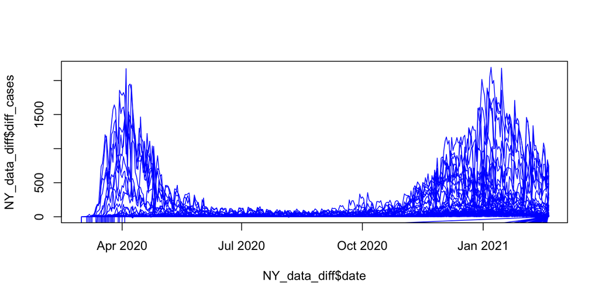

```r
plot(NY_data_diff$date, NY_data_diff$diff_cases, type="l", col="blue",ylim = c(0, max(NY_data_diff$diff_cases)))
```

#Washington

```r
  WAData <- covid_data_filtered[covid_data_filtered$State %in% c("Washington")]

  print(WAData)
```

```
##         FIPS       date County      State cum_cases cum_deaths week
##     1: 53001 2020-03-23  Adams Washington         1          0   10
##     2: 53001 2020-03-24  Adams Washington         1          0   10
##     3: 53001 2020-03-25  Adams Washington         1          0   10
##     4: 53001 2020-03-26  Adams Washington         3          0   10
##     5: 53001 2020-03-27  Adams Washington         5          0   10
##    ---
## 13276: 53077 2021-02-16 Yakima Washington     27045        410   57
## 13277: 53077 2021-02-17 Yakima Washington     27107        412   57
## 13278: 53077 2021-02-18 Yakima Washington     27177        413   57
## 13279: 53077 2021-02-19 Yakima Washington     27224        413   57
## 13280: 53077 2021-02-20 Yakima Washington     27279        413   57
##        TotalPopEst2019
##     1:           19983
##     2:           19983
##     3:           19983
##     4:           19983
##     5:           19983
##    ---
## 13276:          250873
## 13277:          250873
## 13278:          250873
## 13279:          250873
## 13280:          250873
```

```r
  WA_data_diff <- WAData %>%
  mutate(diff_cases = cum_cases - lag(cum_cases, default = first(cum_cases)))
  print(WA_data_diff)
```

```
##         FIPS       date County      State cum_cases cum_deaths week
##     1: 53001 2020-03-23  Adams Washington         1          0   10
##     2: 53001 2020-03-24  Adams Washington         1          0   10
##     3: 53001 2020-03-25  Adams Washington         1          0   10
##     4: 53001 2020-03-26  Adams Washington         3          0   10
##     5: 53001 2020-03-27  Adams Washington         5          0   10
##    ---
## 13276: 53077 2021-02-16 Yakima Washington     27045        410   57
## 13277: 53077 2021-02-17 Yakima Washington     27107        412   57
## 13278: 53077 2021-02-18 Yakima Washington     27177        413   57
## 13279: 53077 2021-02-19 Yakima Washington     27224        413   57
## 13280: 53077 2021-02-20 Yakima Washington     27279        413   57
##        TotalPopEst2019 diff_cases
##     1:           19983          0
##     2:           19983          0
##     3:           19983          0
##     4:           19983          2
##     5:           19983          2
##    ---
## 13276:          250873         75
## 13277:          250873         62
## 13278:          250873         70
## 13279:          250873         47
## 13280:          250873         55
```

#Washington Plot

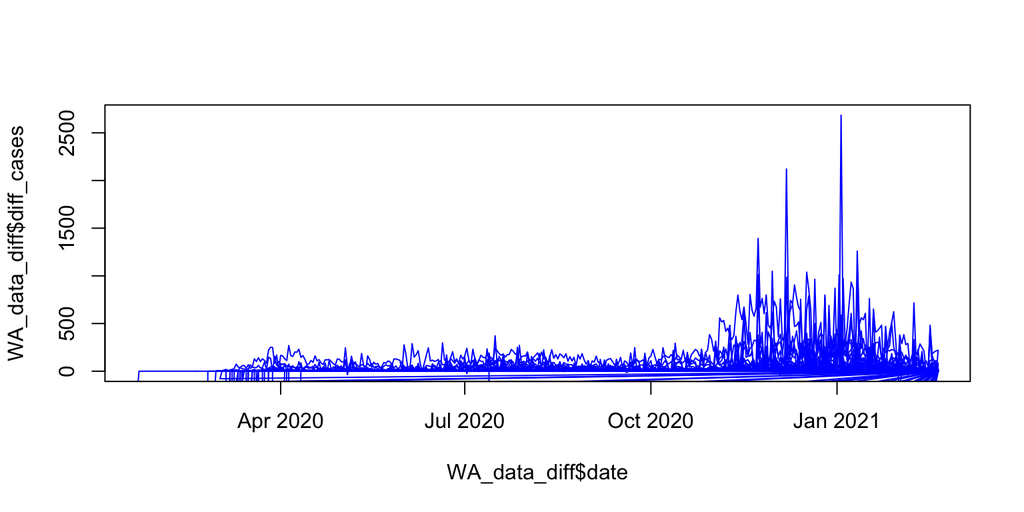

```r
plot(WA_data_diff$date, WA_data_diff$diff_cases, type="l", col="blue",ylim = c(0, max(WA_data_diff$diff_cases)))
```

#Florida

```r
  FLData <- covid_data_filtered[covid_data_filtered$State %in% c("Florida")]

  print(FLData)
```

```
##         FIPS       date     County   State cum_cases cum_deaths week
##     1: 12001 2020-03-10    Alachua Florida         1          0    8
##     2: 12001 2020-03-11    Alachua Florida         1          0    8
##     3: 12001 2020-03-12    Alachua Florida         2          0    8
##     4: 12001 2020-03-13    Alachua Florida         3          0    8
##     5: 12001 2020-03-14    Alachua Florida         3          0    8
##    ---
## 22637: 12133 2021-02-16 Washington Florida      2583         39   57
## 22638: 12133 2021-02-17 Washington Florida      2585         40   57
## 22639: 12133 2021-02-18 Washington Florida      2589         40   57
## 22640: 12133 2021-02-19 Washington Florida      2590         41   57
## 22641: 12133 2021-02-20 Washington Florida      2595         41   57
##        TotalPopEst2019
##     1:          269043
##     2:          269043
##     3:          269043
##     4:          269043
##     5:          269043
##    ---
## 22637:           25473
## 22638:           25473
## 22639:           25473
## 22640:           25473
## 22641:           25473
```

```r
  FL_data_diff <- FLData %>%
  mutate(diff_cases = cum_cases - lag(cum_cases, default = first(cum_cases)))
  print(FL_data_diff)
```

```
##         FIPS       date     County   State cum_cases cum_deaths week
##     1: 12001 2020-03-10    Alachua Florida         1          0    8
##     2: 12001 2020-03-11    Alachua Florida         1          0    8
##     3: 12001 2020-03-12    Alachua Florida         2          0    8
##     4: 12001 2020-03-13    Alachua Florida         3          0    8
##     5: 12001 2020-03-14    Alachua Florida         3          0    8
##    ---
## 22637: 12133 2021-02-16 Washington Florida      2583         39   57
## 22638: 12133 2021-02-17 Washington Florida      2585         40   57
## 22639: 12133 2021-02-18 Washington Florida      2589         40   57
## 22640: 12133 2021-02-19 Washington Florida      2590         41   57
## 22641: 12133 2021-02-20 Washington Florida      2595         41   57
##        TotalPopEst2019 diff_cases
##     1:          269043          0
##     2:          269043          0
##     3:          269043          1
##     4:          269043          1
##     5:          269043          0
##    ---
## 22637:           25473          3
## 22638:           25473          2
## 22639:           25473          4
## 22640:           25473          1
## 22641:           25473          5
```

#Florida Plot

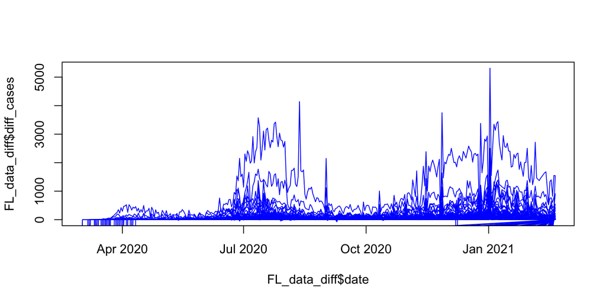

```r
plot(FL_data_diff$date, FL_data_diff$diff_cases, type="l", col="blue",ylim = c(0, max(FL_data_diff$diff_cases)))
```

2. Create **weekly new** cases per 100k `weekly_case_per100k`. Plot the spaghetti plots of `weekly_case_per100k` by state. Use `TotalPopEst2019` as population.

```r
  covid_rate_per100k <- covid_rate %>%
  mutate(diff_cases = cum_cases - lag(cum_cases, default = first(cum_cases)))
  print(covid_rate_per100k)
```

```
##           FIPS       date  County       State cum_cases cum_deaths week
##       1: 10001 2020-03-18    Kent    Delaware         3          0    9
##       2: 10001 2020-03-19    Kent    Delaware         4          0    9
##       3: 10001 2020-03-20    Kent    Delaware         4          0    9
##       4: 10001 2020-03-21    Kent    Delaware         5          0    9
##       5: 10001 2020-03-22    Kent    Delaware         5          0   10
##      ---
## 1008980:  9015 2021-02-16 Windham Connecticut      8963        172   57
## 1008981:  9015 2021-02-17 Windham Connecticut      8974        174   57
## 1008982:  9015 2021-02-18 Windham Connecticut      8976        174   57
## 1008983:  9015 2021-02-19 Windham Connecticut      9028        176   57
## 1008984:  9015 2021-02-20 Windham Connecticut      9028        176   57
##          TotalPopEst2019 diff_cases
##       1:          180786          0
##       2:          180786          1
##       3:          180786          0
##       4:          180786          1
##       5:          180786          0
##      ---
## 1008980:          116782         19
## 1008981:          116782         11
## 1008982:          116782          2
## 1008983:          116782         52
## 1008984:          116782          0
```

```r
  covid_rate_per100k2 <- covid_rate_per100k
  covid_rate_per100k2$sum_every_7_rows <- rollapply(covid_rate_per100k2$diff_cases, width = 7, FUN = sum, by = 7, fill = NA)
  print(covid_rate_per100k2)
```

```
##           FIPS       date  County       State cum_cases cum_deaths week
##       1: 10001 2020-03-18    Kent    Delaware         3          0    9
##       2: 10001 2020-03-19    Kent    Delaware         4          0    9
##       3: 10001 2020-03-20    Kent    Delaware         4          0    9
##       4: 10001 2020-03-21    Kent    Delaware         5          0    9
##       5: 10001 2020-03-22    Kent    Delaware         5          0   10
##      ---
## 1008980:  9015 2021-02-16 Windham Connecticut      8963        172   57
## 1008981:  9015 2021-02-17 Windham Connecticut      8974        174   57
## 1008982:  9015 2021-02-18 Windham Connecticut      8976        174   57
## 1008983:  9015 2021-02-19 Windham Connecticut      9028        176   57
## 1008984:  9015 2021-02-20 Windham Connecticut      9028        176   57
##          TotalPopEst2019 diff_cases sum_every_7_rows
##       1:          180786          0               NA
##       2:          180786          1               NA
##       3:          180786          0               NA
##       4:          180786          1                7
##       5:          180786          0               NA
##      ---
## 1008980:          116782         19               NA
## 1008981:          116782         11               NA
## 1008982:          116782          2               NA
## 1008983:          116782         52               NA
## 1008984:          116782          0               NA
```

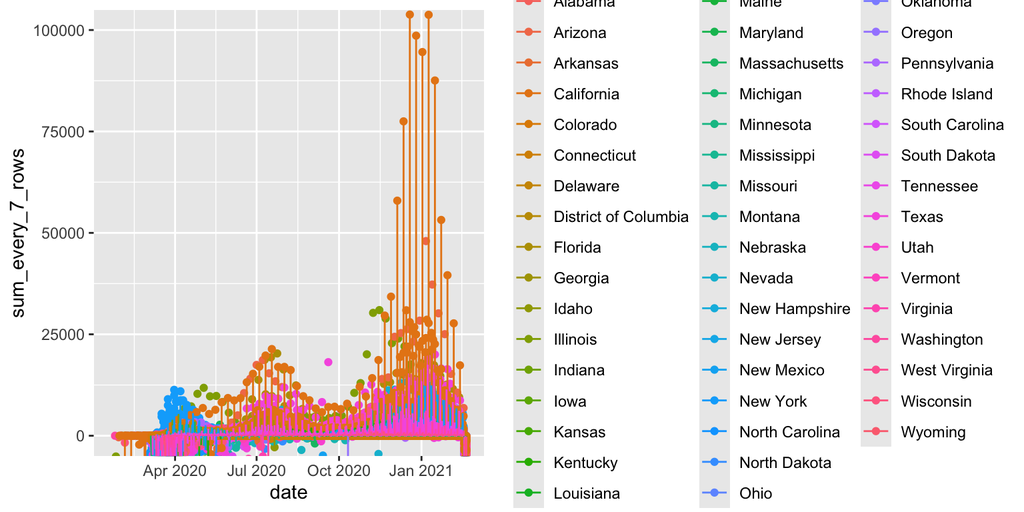

```r
  covid_rate_per100k3 <- covid_rate_per100k2[complete.cases(covid_rate_per100k2$sum_every_7_rows), ]
  ggplot(covid_rate_per100k2, aes(date, sum_every_7_rows, group = State, color = State)) + geom_point() + geom_line() + coord_cartesian(ylim = c(0,100000))
```

iii) Summarize the COVID case trend among states based on the plot in ii). What could be the possible reasons to explain the variabilities?

Based on the plot in part two, it is evident that the state with the most new cases each week was certainly California. Other states, such as North Dakota, have much less variability and remain with a small number of cases each week. This is very likely because these smaller states have much less urban centers, and thus the smaller populations allow for less COVID spread.

## 3.3 COVID death trend

1. For each month in 2020, plot the monthly deaths per 100k heatmap by state on US map. Use the same color range across months. (Hints: Set `limits` argument in `scale_fill_gradient()` or use `facet_wrap()`; use `lubridate::month()` and `lubridate::year()` to extract month and year from date; use `tidyr::complete(state, month, fill = list(new_case_per100k = NA))` to complete the missing months with no cases.)

[figure not shown]

```r
  # Convert date to month
covid_data <- covid_rate_per100k3 %>%
  mutate(month = format(date, "%Y-%m"))

# Aggregate monthly cases for each state
monthly_cases <- covid_data %>%
  group_by(State, month) %>%
  mutate(total_cases = sum(cum_deaths))

# Pivot the data for heatmap plotting
heatmap_data <- pivot_wider(monthly_cases, names_from = month, values_from = total_cases)

# Create heatmap using ggplot2
heatmap_plot <- ggplot(heatmap_data, aes(x = heatmap_data$total_cases, y = State, fill = as.numeric(`2020-01`))) +
  scale_fill_gradient(low = "lightblue", high = "darkblue") +
  theme_minimal() +
  labs(title = "Monthly COVID-19 Deaths by US State",
       x = "Month",
       y = "State",
       fill = "Cases") +
  theme(axis.text.x = element_text(angle = 45, hjust = 1))

# Display the heatmap
print(heatmap_plot)
```

2. (Optional) Use `plotly` to animate the monthly maps in i). Does it reveal any systematic way to capture the dynamic changes among states? (Hints: Follow *Appendix 3: Plotly heatmap::* in Module 6 regularization lecture to plot the heatmap using `plotly`. Use `frame` argument in `add_trace()` for animation. `plotly` only recognizes abbreviation of state names. Use `unique(us_map(regions = "states") %>% select(abbr, full))` to get the abbreviation and merge with the data to get state abbreviation.)

# 4 COVID factor

We now try to build a good parsimonious model to find possible factors related to death rate on county level. Let us not take time series into account for the moment and use the total number as of *Feb 1, 2021*.

1. Create the response variable `total_death_per100k` as the total of number of COVID deaths per 100k by *Feb 1, 2021*. We suggest to take log transformation as `log_total_death_per100k = log(total_death_per100k + 1)`. Merge `total_death_per100k` to `county_data` for the following analysis.

```r
  toAdd <- subset(covid_data, date <= as.Date("2021-02-01"))
  total_deaths_per100k <- sum(toAdd$cum_deaths, na.rm = TRUE) / 100000
  county_data$total_death_per100k <- total_deaths_per100k
  print(county_data)
```

```
##        FIPS State        County MedHHInc PerCapitaInc PovertyUnder18Pct
##    1:     0    US United States    61937        32621              18.0
##    2:  1000    AL       Alabama    49881        26846              23.9
##    3:  1001    AL       Autauga    59338        29372              19.3
##    4:  1003    AL       Baldwin    57588        31203              13.9
##    5:  1005    AL       Barbour    34382        18461              43.9
##   ---
## 3275: 72147    PR       Vieques       NA        11156                NA
## 3276: 72149    PR      Villalba       NA        10677                NA
## 3277: 72151    PR       Yabucoa       NA         9148                NA
## 3278: 72153    PR         Yauco       NA         8339                NA
## 3279: 72153    PR         Yauco       NA         8339                NA
##       PovertyAllAgesPct Deep_Pov_All Deep_Pov_Children PovertyUnder18Num
##    1:              13.1         6.25              8.60          12997532
##    2:              16.8         7.61             11.59            255613
```

[output cut: 729 more lines]

2. Select possible variables in `county_data` as covariates. We provide `county_data_sub`, a subset variables from `county_data`, for you to get started. Please add any potential variables as you wish.

Variables to use as covariates in the regression include poverty percentage, per capita income, percent employment (including in the different industries), ruralurban continuum code, population density, and each race percentage.

```
a) Report missing values in your final subset of variables.
```

```r
county_data_sub <- county_data %>%
  select(County, State, FIPS, Deep_Pov_All, PovertyAllAgesPct, PerCapitaInc, UnempRate2019, PctEmpFIRE, PctEmpConstruction, PctEmpTrans, PctEmpMining, PctEmpTrade, PctEmpInformation, PctEmpAgriculture, PctEmpManufacturing, PctEmpServices, PopDensity2010, OwnHomePct, Age65AndOlderPct2010, TotalPop25Plus, Under18Pct2010, Ed2HSDiplomaOnlyPct, Ed3SomeCollegePct, Ed4AssocDegreePct, Ed5CollegePlusPct, ForeignBornPct, Net_International_Migration_Rate_2010_2019, NetMigrationRate1019, NaturalChangeRate1019, TotalPopEst2019, WhiteNonHispanicPct2010, NativeAmericanNonHispanicPct2010, BlackNonHispanicPct2010, AsianNonHispanicPct2010, HispanicPct2010, Type_2015_Update, RuralUrbanContinuumCode2013, UrbanInfluenceCode2013, Perpov_1980_0711, HiCreativeClass2000, HiAmenity, Retirement_Destination_2015_Update)

print(county_data_sub)
```

```
##              County State  FIPS Deep_Pov_All PovertyAllAgesPct PerCapitaInc
##    1: United States    US     0         6.25              13.1        32621
##    2:       Alabama    AL  1000         7.61              16.8        26846
##    3:       Autauga    AL  1001         6.14              13.8        29372
##    4:       Baldwin    AL  1003         4.48               9.8        31203
##    5:       Barbour    AL  1005        12.75              30.9        18461
##   ---
## 3275:       Vieques    PR 72147        23.75                NA        11156
## 3276:      Villalba    PR 72149        24.17                NA        10677
## 3277:       Yabucoa    PR 72151        28.89                NA         9148
## 3278:         Yauco    PR 72153        27.18                NA         8339
## 3279:         Yauco    PR 72153        27.18                NA         8339
##       UnempRate2019 PctEmpFIRE PctEmpConstruction PctEmpTrans PctEmpMining
##    1:           3.7       6.56               6.47        5.23        0.544
##    2:           3.0       5.54               6.54        5.37        0.419
```

[output cut: 129 more lines]

3. Use LASSO to choose a parsimonious model with all available sensible county-level information. **Force in State** in the process. Why we need to force in State? You may use `lambda.1se` to choose a smaller model.

We must force in State in the model because if not, omitting the state variable can lead to biased or misleading results, especially when the data concerns county-level data.

```r
library(glmnet)
county_data <- na.omit(county_data)
predictor_variables <- c("County", "State", "FIPS", "Deep_Pov_All", "PovertyAllAgesPct", "PerCapitaInc", "UnempRate2019", "PctEmpFIRE", "PctEmpConstruction", "PctEmpTrans", "PctEmpMining", "PctEmpTrade" , "PctEmpInformation", "PctEmpAgriculture", "PctEmpManufacturing", "PctEmpServices", "PopDensity2010", "OwnHomePct", "Age65AndOlderPct2010", "TotalPop25Plus", "Under18Pct2010", "Ed2HSDiplomaOnlyPct", "Ed3SomeCollegePct", "Ed4AssocDegreePct", "Ed5CollegePlusPct", "ForeignBornPct", "Net_International_Migration_Rate_2010_2019", "NetMigrationRate1019", "NaturalChangeRate1019", "TotalPopEst2019", "WhiteNonHispanicPct2010", "NativeAmericanNonHispanicPct2010", "BlackNonHispanicPct2010", "AsianNonHispanicPct2010", "HispanicPct2010", "Type_2015_Update", "RuralUrbanContinuumCode2013", "UrbanInfluenceCode2013", "Perpov_1980_0711", "HiCreativeClass2000", "HiAmenity", "Retirement_Destination_2015_Update")

predictors <- subset(county_data, select = c(predictor_variables))
outcome <- county_data$total_death_per100k



lasso_model <- cv.glmnet(as.matrix(predictors), outcome, alpha = 0.05)
best_lambda <- lasso_model$lambda.min

selected_coeffs <- coef(lasso_model, s = best_lambda)

print(selected_coeffs)
```

```
## 43 x 1 sparse Matrix of class "dgCMatrix"
##                                                   s1
## (Intercept)                                 8.19e+01
## County                                      .
## State                                       .
## FIPS                                        .
## Deep_Pov_All                                2.58e-29
## PovertyAllAgesPct                          -4.30e-29
## PerCapitaInc                               -1.27e-32
## UnempRate2019                               .
## PctEmpFIRE                                 -1.99e-28
## PctEmpConstruction                         -3.08e-28
## PctEmpTrans                                -2.41e-28
## PctEmpMining                               -2.95e-28
## PctEmpTrade                                -2.62e-28
## PctEmpInformation                          -2.51e-28
## PctEmpAgriculture                          -3.56e-28
## PctEmpManufacturing                        -3.03e-28
## PctEmpServices                             -5.23e-28
## PopDensity2010                             -2.52e-32
## OwnHomePct                                 -7.67e-29
## Age65AndOlderPct2010                       -9.25e-29
## TotalPop25Plus                              1.93e-34
## Under18Pct2010                             -1.97e-28
## Ed2HSDiplomaOnlyPct                        -9.01e-29
## Ed3SomeCollegePct                          -1.58e-28
## Ed4AssocDegreePct                           .
## Ed5CollegePlusPct                           .
## ForeignBornPct                              .
## Net_International_Migration_Rate_2010_2019 -1.47e-28
## NetMigrationRate1019                        3.90e-31
## NaturalChangeRate1019                      -1.50e-29
## TotalPopEst2019                             7.12e-35
## WhiteNonHispanicPct2010                     3.08e-29
## NativeAmericanNonHispanicPct2010            3.81e-29
## BlackNonHispanicPct2010                     2.03e-30
## AsianNonHispanicPct2010                     .
## HispanicPct2010                             2.07e-29
## Type_2015_Update                            .
## RuralUrbanContinuumCode2013                 1.01e-28
## UrbanInfluenceCode2013                      .
## Perpov_1980_0711                            .
## HiCreativeClass2000                         2.27e-28
## HiAmenity                                   .
## Retirement_Destination_2015_Update          2.22e-28
```

4. Use a quick backward elimination to fine tune the LASSO model from iii). Again **force in State** in the process.

```r
library(glmnet)

predictor_variables <- c("County", "State", "Deep_Pov_All", "PovertyAllAgesPct", "PerCapitaInc", "UnempRate2019", "PctEmpFIRE", "PctEmpConstruction", "PctEmpTrans", "PctEmpMining", "PctEmpTrade" , "PctEmpInformation", "PctEmpAgriculture", "PctEmpManufacturing", "PctEmpServices", "PopDensity2010", "Age65AndOlderPct2010", "TotalPop25Plus", "Under18Pct2010", "Ed2HSDiplomaOnlyPct", "Ed3SomeCollegePct", "Ed4AssocDegreePct", "Ed5CollegePlusPct", "Net_International_Migration_Rate_2010_2019", "NetMigrationRate1019", "NaturalChangeRate1019", "TotalPopEst2019", "WhiteNonHispanicPct2010", "NativeAmericanNonHispanicPct2010", "BlackNonHispanicPct2010", "AsianNonHispanicPct2010", "HispanicPct2010", "Type_2015_Update", "RuralUrbanContinuumCode2013", "Perpov_1980_0711", "HiCreativeClass2000", "HiAmenity", "Retirement_Destination_2015_Update")

predictors <- subset(county_data, select = c(predictor_variables))
outcome <- county_data$total_death_per100k



lasso_model <- cv.glmnet(as.matrix(predictors), outcome, alpha = 0.05)
best_lambda <- lasso_model$lambda.min

selected_coeffs <- coef(lasso_model, s = best_lambda)

print(selected_coeffs)
```

```
## 39 x 1 sparse Matrix of class "dgCMatrix"
##                                                   s1
## (Intercept)                                 8.19e+01
## County                                      .
## State                                       .
## Deep_Pov_All                                1.33e-28
## PovertyAllAgesPct                          -1.09e-28
## PerCapitaInc                               -5.14e-32
## UnempRate2019                              -1.72e-29
## PctEmpFIRE                                 -4.20e-28
## PctEmpConstruction                         -5.61e-28
## PctEmpTrans                                -4.51e-28
## PctEmpMining                               -5.08e-28
## PctEmpTrade                                -4.31e-28
## PctEmpInformation                          -4.62e-28
## PctEmpAgriculture                          -5.59e-28
## PctEmpManufacturing                        -4.83e-28
## PctEmpServices                             -7.18e-28
## PopDensity2010                              6.51e-33
## Age65AndOlderPct2010                       -1.09e-28
## TotalPop25Plus                              9.87e-34
## Under18Pct2010                             -2.28e-28
## Ed2HSDiplomaOnlyPct                        -1.38e-28
## Ed3SomeCollegePct                          -1.91e-28
## Ed4AssocDegreePct                          -6.69e-30
## Ed5CollegePlusPct                           .
## Net_International_Migration_Rate_2010_2019 -1.43e-28
## NetMigrationRate1019                        3.23e-30
## NaturalChangeRate1019                      -7.94e-32
## TotalPopEst2019                             2.45e-35
## WhiteNonHispanicPct2010                     6.60e-29
## NativeAmericanNonHispanicPct2010            6.56e-29
## BlackNonHispanicPct2010                     3.61e-29
## AsianNonHispanicPct2010                     1.17e-29
## HispanicPct2010                             6.09e-29
## Type_2015_Update                           -7.10e-29
## RuralUrbanContinuumCode2013                 1.26e-28
## Perpov_1980_0711                            .
## HiCreativeClass2000                         2.55e-28
## HiAmenity                                  -2.30e-29
## Retirement_Destination_2015_Update          7.20e-29
```

22. If necessary, reduce the model from iv) to a final model with all variables being significant at 0.05 level. Are the linear model assumptions all reasonably met?

6. It has been shown that COVID affects elderly the most. It is also claimed that the COVID death rate among African Americans and Latinos is higher. Does your analysis support these arguments?

7. Based on your final model, summarize your findings. In particular, summarize the state effect controlling for others. Provide intervention recommendations to policy makers to reduce COVID death rate.

8. What else can we do to improve our model? What other important information we may have missed?

In order to improve the model, we could include more variables and more samples. This would improve accuracy. Some important information that was missed could include access to hospital, and also access to clean facilities and drinking water.

9. (Optional) Would your findings be very different if you had refined the data in some way or imputed the missing values in part ii). Check PCA lecture, section 10 for imputations via `softImpute`.

# 5 Executive summary

Please summarize this project as follows (no more than one page):

- Goal of the study
- Data
  - Source and a brief description of the data
  - How do you assemble them together (mostly done by our team but you may present them as if you have done so)
- Analyses
- Methods used
- Findings
- Limitations

Despite these findings, the model also had several limitations, largely due to the reasons listed as follows:

In order to improve the model, we could include more variables and more samples. This would improve accuracy. Some important information that was missed could include access to hospital, and also access to clean facilities and drinking water.

These are the overall purpose, conclusions, and limitations of the LASSO regression model.

# 6 Potential final projects

## 6.1 Does the govenment lockdown policy work in reducing covid death rates?

Please talk to Linda if interested in this.

You may use the available data together with `covid_intervention` as well as more potential data not included here.

## 6.2 Do vaccinations help reducing death rates from `COVID`?

Please talk to Linda if interested in this.

# 7 Appendix 1: Data description

A detailed summary of the variables in each data set follows:

## 7.1 Infection and fatality data

- date: Date
- county: County name
- state: State name
- fips: County code that uniquely identifies a county
- cases: Number of cumulative COVID-19 infections
- deaths: Number of cumulative COVID-19 deaths

## 7.2 Socioeconomic demographics

*Income*: Poverty level and household income

- PovertyUnder18Pct: Poverty rate for children age 0-17, 2018
- Deep_Pov_All: Deep poverty, 2014-18
- Deep_Pov_Children: Deep poverty for children, 2014-18
- PovertyAllAgesPct: Poverty rate, 2018
- MedHHInc: Median household income, 2018 (In 2018 dollars)
- PerCapitaInc: Per capita income in the past 12 months (In 2018 inflation adjusted dollars), 2014-18
- PovertyAllAgesNum: Number of people of all ages in poverty, 2018
- PovertyUnder18Num: Number of people age 0-17 in poverty, 2018

*Jobs*: Employment type, rate, and change

- UnempRate2007-2019: Unemployment rate, 2007-2019
- NumEmployed2007-2019: Employed, 2007-2019
- NumUnemployed2007-2019: Unemployed, 2007-2019
- PctEmpChange1019: Percent employment change, 2010-19
- PctEmpChange1819: Percent employment change, 2018-19
- PctEmpChange0719: Percent employment change, 2007-19
- PctEmpChange0710: Percent employment change, 2007-10
- NumCivEmployed: Civilian employed population 16 years and over, 2014-18
- NumCivLaborforce2007-2019: Civilian labor force, 2007-2019
- PctEmpFIRE: Percent of the civilian labor force 16 and over employed in finance and insurance, and real estate and rental and leasing, 2014-18
- PctEmpConstruction: Percent of the civilian labor force 16 and over employed in construction, 2014-18
- PctEmpTrans: Percent of the civilian labor force 16 and over employed in transportation, warehousing and utilities, 2014-18
- PctEmpMining: Percent of the civilian labor force 16 and over employed in mining, quarrying, oil and gas extraction, 2014-18
- PctEmpTrade: Percent of the civilian labor force 16 and over employed in wholesale and retail trade, 2014-18
- PctEmpInformation: Percent of the civilian labor force 16 and over employed in information services, 2014-18
- PctEmpAgriculture: Percent of the civilian labor force 16 and over employed in agriculture, forestry, fishing, and hunting, 2014-18
- PctEmpManufacturing: Percent of the civilian labor force 16 and over employed in manufacturing, 2014-18
- PctEmpServices: Percent of the civilian labor force 16 and over employed in services, 2014-18
- PctEmpGovt: Percent of the civilian labor force 16 and over employed in public administration, 2014-18

*People*: Population size, density, education level, race, age, household size, and migration rates

- PopDensity2010: Population density, 2010
- LandAreaSQMiles2010: Land area in square miles, 2010
- TotalHH: Total number of households, 2014-18
- TotalOccHU: Total number of occupied housing units, 2014-18
- AvgHHSize: Average household size, 2014-18
- OwnHomeNum: Number of owner occupied housing units, 2014-18
- OwnHomePct: Percent of owner occupied housing units, 2014-18
- NonEnglishHHPct: Percent of non-English speaking households of total households, 2014-18
- HH65PlusAlonePct: Percent of persons 65 or older living alone, 2014-18
- FemaleHHPct: Percent of female headed family households of total households, 2014-18
- FemaleHHNum: Number of female headed family households, 2014-18
- NonEnglishHHNum: Number of non-English speaking households, 2014-18
- HH65PlusAloneNum: Number of persons 65 years or older living alone, 2014-18
- Age65AndOlderPct2010: Percent of population 65 or older, 2010
- Age65AndOlderNum2010: Population 65 years or older, 2010
- TotalPop25Plus: Total population 25 and older, 2014-18 - 5-year average
- Under18Pct2010: Percent of population under age 18, 2010
- Under18Num2010: Population under age 18, 2010
- Ed1LessThanHSPct: Percent of persons with no high school diploma or GED, adults 25 and over, 2014-18
- Ed2HSDiplomaOnlyPct: Percent of persons with a high school diploma or GED only, adults 25 and over, 2014-18
- Ed3SomeCollegePct: Percent of persons with some college experience, adults 25 and over, 2014-18
- Ed4AssocDegreePct: Percent of persons with an associate’s degree, adults 25 and over, 2014-18
- Ed5CollegePlusPct: Percent of persons with a 4-year college degree or more, adults 25 and over, 2014-18
- Ed1LessThanHSNum: No high school, adults 25 and over, 2014-18
- Ed2HSDiplomaOnlyNum: High school only, adults 25 and over, 2014-18
- Ed3SomeCollegeNum: Some college experience, adults 25 and over, 2014-18
- Ed4AssocDegreeNum: Number of persons with an associate’s degree, adults 25 and over, 2014-18
- Ed5CollegePlusNum: College degree 4-years or more, adults 25 and over, 2014-18
- ForeignBornPct: Percent of total population foreign born, 2014-18
- ForeignBornEuropePct: Percent of persons born in Europe, 2014-18
- ForeignBornMexPct: Percent of persons born in Mexico, 2014-18
- ForeignBornCentralSouthAmPct: Percent of persons born in Central or South America, 2014-18
- ForeignBornAsiaPct: Percent of persons born in Asia, 2014-18
- ForeignBornCaribPct: Percent of persons born in the Caribbean, 2014-18
- ForeignBornAfricaPct: Percent of persons born in Africa, 2014-18
- ForeignBornNum: Number of people foreign born, 2014-18
- ForeignBornCentralSouthAmNum: Number of persons born in Central or South America, 2014-18
- ForeignBornEuropeNum: Number of persons born in Europe, 2014-18
- ForeignBornMexNum: Number of persons born in Mexico, 2014-18
- ForeignBornAfricaNum: Number of persons born in Africa, 2014-18
- ForeignBornAsiaNum: Number of persons born in Asia, 2014-18
- ForeignBornCaribNum: Number of persons born in the Caribbean, 2014-18
- Net_International_Migration_Rate_2010_2019: Net international migration rate, 2010-19
- Net_International_Migration_2010_2019: Net international migration, 2010-19
- Net_International_Migration_2000_2010: Net international migration, 2000-10
- Immigration_Rate_2000_2010: Net international migration rate, 2000-10
- NetMigrationRate0010: Net migration rate, 2000-10
- NetMigrationRate1019: Net migration rate, 2010-19
- NetMigrationNum0010: Net migration, 2000-10
- NetMigration1019: Net Migration, 2010-19
- NaturalChangeRate1019: Natural population change rate, 2010-19
- NaturalChangeRate0010: Natural population change rate, 2000-10
- NaturalChangeNum0010: Natural change, 2000-10
- NaturalChange1019: Natural population change, 2010-19
- TotalPop2010: Population size 4/1/2010 Census
- TotalPopEst2010: Population size 7/1/2010
- TotalPopEst2011: Population size 7/1/2011
- TotalPopEst2012: Population size 7/1/2012
- TotalPopEst2013: Population size 7/1/2013
- TotalPopEst2014: Population size 7/1/2014
- TotalPopEst2015: Population size 7/1/2015
- TotalPopEst2016: Population size 7/1/2016
- TotalPopEst2017: Population size 7/1/2017
- TotalPopEst2018: Population size 7/1/2018
- TotalPopEst2019: Population size 7/1/2019
- TotalPopACS: Total population, 2014-18 - 5-year average
- TotalPopEstBase2010: County Population estimate base 4/1/2010
- NonHispanicAsianPopChangeRate0010: Population change rate Non-Hispanic Asian, 2000-10
- PopChangeRate1819: Population change rate, 2018-19
- PopChangeRate1019: Population change rate, 2010-19
- PopChangeRate0010: Population change rate, 2000-10
- NonHispanicNativeAmericanPopChangeRate0010: Population change rate Non-Hispanic Native American, 2000-10
- HispanicPopChangeRate0010: Population change rate Hispanic, 2000-10
- MultipleRacePopChangeRate0010: Population change rate multiple race, 2000-10
- NonHispanicWhitePopChangeRate0010: Population change rate Non-Hispanic White, 2000-10
- NonHispanicBlackPopChangeRate0010: Population change rate Non-Hispanic African American, 2000-10
- MultipleRacePct2010: Percent multiple race, 2010
- WhiteNonHispanicPct2010: Percent Non-Hispanic White, 2010
- NativeAmericanNonHispanicPct2010: Percent Non-Hispanic Native American, 2010
- BlackNonHispanicPct2010: Percent Non-Hispanic African American, 2010
- AsianNonHispanicPct2010: Percent Non-Hispanic Asian, 2010
- HispanicPct2010: Percent Hispanic, 2010
- MultipleRaceNum2010: Population size multiple race, 2010
- WhiteNonHispanicNum2010: Population size Non-Hispanic White, 2010
- BlackNonHispanicNum2010: Population size Non-Hispanic African American, 2010
- NativeAmericanNonHispanicNum2010: Population size Non-Hispanic Native American, 2010
- AsianNonHispanicNum2010: Population size Non-Hispanic Asian, 2010
- HispanicNum2010: Population size Hispanic, 2010

##County classifications

Type of county (rural or urban on a rural-urban continuum scale)

- Type_2015_Recreation_NO: Recreation counties, 2015 edition
- Type_2015_Farming_NO: Farming-dependent counties, 2015 edition
- Type_2015_Mining_NO: Mining-dependent counties, 2015 edition
- Type_2015_Government_NO: Federal/State government-dependent counties, 2015 edition
- Type_2015_Update: County typology economic types, 2015 edition
- Type_2015_Manufacturing_NO: Manufacturing-dependent counties, 2015 edition
- Type_2015_Nonspecialized_NO: Nonspecialized counties, 2015 edition
- RecreationDependent2000: Nonmetro recreation-dependent, 1997-00
- ManufacturingDependent2000: Manufacturing-dependent, 1998-00
- FarmDependent2003: Farm-dependent, 1998-00
- EconomicDependence2000: Economic dependence, 1998-00
- RuralUrbanContinuumCode2003: Rural-urban continuum code, 2003
- UrbanInfluenceCode2003: Urban influence code, 2003
- RuralUrbanContinuumCode2013: Rural-urban continuum code, 2013
- UrbanInfluenceCode2013: Urban influence code, 2013
- Noncore2013: Nonmetro noncore, outside Micropolitan and Metropolitan, 2013
- Micropolitan2013: Micropolitan, 2013
- Nonmetro2013: Nonmetro, 2013
- Metro2013: Metro, 2013
- Metro_Adjacent2013: Nonmetro, adjacent to metro area, 2013
- Noncore2003: Nonmetro noncore, outside Micropolitan and Metropolitan, 2003
- Micropolitan2003: Micropolitan, 2003
- Metro2003: Metro, 2003
- Nonmetro2003: Nonmetro, 2003
- NonmetroNotAdj2003: Nonmetro, nonadjacent to metro area, 2003
- NonmetroAdj2003: Nonmetro, adjacent to metro area, 2003
- Oil_Gas_Change: Change in the value of onshore oil and natural gas production, 2000-11
- Gas_Change: Change in the value of onshore natural gas production, 2000-11
- Oil_Change: Change in the value of onshore oil production, 2000-11
- Hipov: High poverty counties, 2014-18
- Perpov_1980_0711: Persistent poverty counties, 2015 edition
- PersistentChildPoverty_1980_2011: Persistent child poverty counties, 2015 edition
- PersistentChildPoverty2004: Persistent child poverty counties, 2004
- PersistentPoverty2000: Persistent poverty counties, 2004
- Low_Education_2015_update: Low education counties, 2015 edition
- LowEducation2000: Low education, 2000
- HiCreativeClass2000: Creative class, 2000
- HiAmenity: High natural amenities
- RetirementDestination2000: Retirement destination, 1990-00
- Low_Employment_2015_update: Low employment counties, 2015 edition
- Population_loss_2015_update: Population loss counties, 2015 edition
- Retirement_Destination_2015_Update: Retirement destination counties, 2015 edition

# 8 Appendix 2: Data cleaning

The raw data sets are dirty and need transforming before we can do our EDA. It takes time and efforts to clean and merge different data sources so we provide the final output of the cleaned and merged data. The cleaning procedure is as follows. Please read through to understand what is in the cleaned data. We set `eval = data_cleaned` in the following cleaning chunks so that these cleaning chunks will only run if any of `data/covid_county.csv`, `data/covid_rates.csv` or `data/covid_intervention.csv` does not exist.

```r
# Indicator to check whether the data files exist
data_cleaned <- !(file.exists("data/covid_county.csv") &
                    file.exists("data/covid_rates.csv") &
                    file.exists("data/covid_intervention.csv"))
```

We first read in the table using `data.table::fread()`, as we did last time.

```r
# COVID case/mortality rate data
covid_rates <- fread("/Users/nicholasmcgowan/Downloads/Homework 3/data/us_counties.csv", na.strings = c("NA", "", "."))
nyc <- fread("/Users/nicholasmcgowan/Downloads/Homework 3/data/nycdata.csv", na.strings = c("NA", "", "."))

# Socioeconomic data
income <- fread("/Users/nicholasmcgowan/Downloads/Homework 3/data/income.csv", na.strings = c("NA", "", "."))
jobs <- fread("/Users/nicholasmcgowan/Downloads/Homework 3/data/jobs.csv", na.strings = c("NA", "", "."))
people <- fread("/Users/nicholasmcgowan/Downloads/Homework 3/data/people.csv", na.strings = c("NA", "", "."))
county_class <- fread("/Users/nicholasmcgowan/Downloads/Homework 3/data/county_classifications.csv", na.strings = c("NA", "", "."))

# Internvention policy data
int_dates <- fread("/Users/nicholasmcgowan/Downloads/Homework 3/data/intervention_dates.csv", na.strings = c("NA", "", "."))
```

## 8.1 Clean NYC data

The original NYC data contains more information than we need. We extract only the number of cases and deaths and format it the same as the `covid_rates` data.

```r
# NYC county fips matching table
nyc_fips <- data.table(FIPS = c('36005', '36047', '36061', '36081', '36085'),
                       County = c("BX", "BK", "MN", "QN", "SI"))

# nyc case
nyc_case <- nyc[,.(date = as.Date(date_of_interest, "%m/%d/%Y"),
                   BX = BX_CASE_COUNT,
                   BK = BK_CASE_COUNT,
                   MN = MN_CASE_COUNT,
                   QN = QN_CASE_COUNT,
                   SI = SI_CASE_COUNT)]

nyc_case %<>%
  pivot_longer(cols = BX:SI,
               names_to = "County",
               values_to = "cases") %>%
  arrange(date) %>%
  group_by(County) %>%
  mutate(cum_cases = cumsum(cases))

# nyc death
nyc_death <- nyc[,.(date = as.Date(date_of_interest, "%m/%d/%Y"),
                   BX = BX_DEATH_COUNT,
                   BK = BK_DEATH_COUNT,
                   MN = MN_DEATH_COUNT,
                   QN = QN_DEATH_COUNT,
                   SI = SI_DEATH_COUNT)]

nyc_death %<>%
  pivot_longer(cols = BX:SI,
               names_to = "County",
               values_to = "deaths") %>%
  arrange(date) %>%
  group_by(County) %>%
  mutate(cum_deaths = cumsum(deaths))

nyc_rates <- merge(nyc_case,
                   nyc_death,
                   by = c("date", "County"),
                   all.x= T)

nyc_rates <- merge(nyc_rates,
                   nyc_fips,
                   by = "County")

nyc_rates$State <- "New York"
nyc_rates %<>%
  select(date, FIPS, County, State, cum_cases, cum_deaths) %>%
  arrange(FIPS, date)
```

## 8.2 Continental US cases

We only consider cases and death in continental US. Alaska, Hawaii, and Puerto Rico have 02, 15, and 72 as their respective first 2 digits of their FIPS. We use the `%/%` operator for integer division to get the first 2 digits of FIPS. We also remove Virgin Islands and Northern Mariana Islands. All data of counties in NYC are aggregated as `County == "New York City"` in `covid_rates` with no FIPS, so we combine the NYC data into `covid_rate`.

```r
covid_rates <- covid_rates %>%
  arrange(fips, date) %>%
  filter(!(fips %/% 1000 %in% c(2, 15, 72))) %>%
  filter(county != "New York City") %>%
  filter(!(state %in% c("Virgin Islands", "Northern Mariana Islands"))) %>%
  rename(FIPS = "fips",
         County = "county",
         State = "state",
         cum_cases = "cases",
         cum_deaths = "deaths")


covid_rates$date <- as.Date(covid_rates$date)

covid_rates <- rbind(covid_rates,
                     nyc_rates)
```

## 8.3 COVID date to week

We set the week of Jan 21, 2020 (the first case of COVID case in US) as the first week (2020-01-19 to 2020-01-25).

```r
covid_rates[, week := (interval("2020-01-19", date) %/% weeks(1)) + 1]
```

## 8.4 COVID infection/mortality rates

Merge the `TotalPopEst2019` variable from the demographic data with `covid_rates` by FIPS.

```r
covid_rates <- merge(covid_rates[!is.na(FIPS)],
                     people[,.(FIPS = as.character(FIPS),
                                   TotalPopEst2019)],
                     by = "FIPS",
                     all.x = TRUE)
```

## 8.5 NA in COVID data

NA values in the `covid_rates` data set correspond to a county not having confirmed cases/deaths. We replace the NA values in these columns with zeros. FIPS for Kansas city, Missouri, Rhode Island and some others are missing. We drop them for the moment and output the data up to week 57 as `covid_rates.csv`.

```r
covid_rates$cum_cases[is.na(covid_rates$cum_cases)] <- 0
covid_rates$cum_deaths[is.na(covid_rates$cum_deaths)] <- 0
```

```r
fwrite(covid_rates %>%
         filter(week < 58) %>%
         arrange(FIPS, date),
       "/Users/nicholasmcgowan/Downloads/Homework 3/data/covid_rates.csv")
```

## 8.6 Formatting date in `int_dates`

We convert the columns representing dates in `int_dates` to R Date types using `as.Date()`. We will need to specify that the `origin` parameter is `"0001-01-01"`. We output the data as `covid_intervention.csv`.

```r
int_dates <- int_dates[-1,]
date_cols <- names(int_dates)[-(1:3)]
int_dates[, (date_cols) := lapply(.SD, as.Date, origin = "0001-01-01"),
          .SDcols = date_cols]

fwrite(int_dates, "/Users/nicholasmcgowan/Downloads/Homework 3/data/covid_intervention.csv")
```

## 8.7 Merge demographic data

Merge the demographic data sets by FIPS and output as `covid_county.csv`.

```r
countydata <-
  merge(x = income,
        y = merge(
          x = people,
          y = jobs,
          by = c("FIPS", "State", "County")),
        by = c("FIPS", "State", "County"),
        all = TRUE)


countydata <-
  merge(
    x = countydata,
    y = county_class %>% rename(FIPS = FIPStxt),
    by = c("FIPS", "State", "County"),
    all = TRUE
  )

# Check dimensions
# They are now 3279 x 208
dim(countydata)
```

```
## [1] 3279  208
```

```r
fwrite(countydata, "/Users/nicholasmcgowan/Downloads/Homework 3/data/covid_county.csv")
```

```r
  print(covid_rate)
```

```
##           FIPS       date  County       State cum_cases cum_deaths week
##       1: 10001 2020-03-18    Kent    Delaware         3          0    9
##       2: 10001 2020-03-19    Kent    Delaware         4          0    9
##       3: 10001 2020-03-20    Kent    Delaware         4          0    9
##       4: 10001 2020-03-21    Kent    Delaware         5          0    9
##       5: 10001 2020-03-22    Kent    Delaware         5          0   10
##      ---
## 1008980:  9015 2021-02-16 Windham Connecticut      8963        172   57
## 1008981:  9015 2021-02-17 Windham Connecticut      8974        174   57
## 1008982:  9015 2021-02-18 Windham Connecticut      8976        174   57
## 1008983:  9015 2021-02-19 Windham Connecticut      9028        176   57
## 1008984:  9015 2021-02-20 Windham Connecticut      9028        176   57
##          TotalPopEst2019
##       1:          180786
##       2:          180786
##       3:          180786
##       4:          180786
##       5:          180786
##      ---
## 1008980:          116782
## 1008981:          116782
## 1008982:          116782
## 1008983:          116782
## 1008984:          116782
```